# Solucionario Nº 5

Curso: POL304 - Estadística para el análisis político 2

Jefes de práctica: Alexander Benites, Chiara Zamora y Airam Bello

Ciclo 2023-2

### 1. Unificación de datos

Cargue dos bases de datos que se encuentran en estos links:

criminal_eap.xlsx -> https://github.com/Alexanderbenit7/EAP2_2023-2/blob/main/data/criminal_eap.xlsx order_eap.xlsx -> https://github.com/Alexanderbenit7/EAP2_2023-2/blob/main/data/order_eap.xlsx

```r
library(rio)
criminal = import("https://github.com/Alexanderbenit7/EAP2_2023-2/raw/main/data/criminal_eap.xlsx")
order = import("https://github.com/Alexanderbenit7/EAP2_2023-2/raw/main/data/order_eap.xlsx")
```

Cambie los nombres de las columnas con este código:

```r
colnames(criminal) = c("country","year","index_criminal","investigation","adjudication","correctional",
                      "impartial","system1","system2","process")

colnames(order) = c("country","year","index_order","controlled","civil_conflict","violence")
```

Merge:

```r
data = merge(criminal, order, by = "country")
```

Quedese solo con las variables necesarias para realizar un EFA:

```r
efa = data[,c(4:10,13:15)]
```

### Preguntas:

#### Pregunta 1

Calcule una matriz de correlaciones con todas las variables y responda a lo siguiente:

1.1. ¿Con qué otras variables la variable *correctional* muestra una correlación muy alta (igual a 0.8 o mayor)? 1.2. ¿Cuál es la variable que muestra la correlación más baja con las demás variables de la matriz?

```r
library(polycor)
corMatrix=polycor::hetcor(efa)$correlations
round(corMatrix,2)
```

```
##                investigation adjudication correctional impartial system1
## investigation           1.00         0.82         0.79      0.62    0.80
## adjudication            0.82         1.00         0.84      0.68    0.78
## correctional            0.79         0.84         1.00      0.72    0.79
## impartial               0.62         0.68         0.72      1.00    0.71
## system1                 0.80         0.78         0.79      0.71    1.00
## system2                 0.65         0.66         0.64      0.69    0.82
## process                 0.78         0.79         0.85      0.80    0.87
## controlled              0.73         0.71         0.75      0.56    0.69
## civil_conflict          0.26         0.24         0.24      0.27    0.35
## violence                0.75         0.72         0.80      0.58    0.69
##                system2 process controlled civil_conflict violence
## investigation     0.65    0.78       0.73           0.26     0.75
## adjudication      0.66    0.79       0.71           0.24     0.72
## correctional      0.64    0.85       0.75           0.24     0.80
## impartial         0.69    0.80       0.56           0.27     0.58
## system1           0.82    0.87       0.69           0.35     0.69
## system2           1.00    0.81       0.48           0.22     0.50
## process           0.81    1.00       0.70           0.36     0.75
## controlled        0.48    0.70       1.00           0.32     0.70
## civil_conflict    0.22    0.36       0.32           1.00     0.18
## violence          0.50    0.75       0.70           0.18     1.00
```

1.1. Rspta: adjudication, process y violence 1.2. Rspta: civil_conflict

#### Pregunta 2:

¿Cuál de las siguientes afirmaciones es falsa? Responda en base a la realización de las pruebas correspondientes:

A. Existe un Overall MSA bastante alto, por lo que se puede proceder con el análisis factorial exploratorio B. No podemos descartar la hipótesis que plantea que la matriz de correlación analizada en una matriz identidad. C. Se tiene suficiente evidencia para rechazar la hipótesis que plantea que la matriz de correlación analizada es una matriz singular.

```r
library(psych)
psych::KMO(corMatrix)
```

```
## Kaiser-Meyer-Olkin factor adequacy
## Call: psych::KMO(r = corMatrix)
## Overall MSA =  0.93
## MSA for each item =
##  investigation   adjudication   correctional      impartial        system1
##           0.95           0.95           0.93           0.96           0.93
##        system2        process     controlled civil_conflict       violence
##           0.87           0.90           0.96           0.77           0.93
```

```r
cortest.bartlett(corMatrix,n=nrow(efa))$p.value>0.05
```

```
## [1] FALSE
```

```r
library(matrixcalc)
is.singular.matrix(corMatrix)
```

```
## [1] FALSE
```

Rspta. B. No podemos descartar la hipótesis que plantea que la matriz de correlación analizada en una matriz identidad.

#### Pregunta 3:

Se le pide realizar un análisis factorial exploratorio con dos factores. Sobre el análisis realizado, ¿qué variable aportó más a los factores?

A. impartial B. civil_conflict C. process

```r
library(GPArotation)
resfa <- fa(efa,
            nfactors = 2,
            cor = 'mixed',
            rotate = "varimax",
            fm="minres")
print(resfa$loadings)
```

```
##
## Loadings:
##                MR1   MR2
## investigation  0.738 0.487
## adjudication   0.718 0.516
## correctional   0.783 0.496
## impartial      0.466 0.649
## system1        0.565 0.739
## system2        0.274 0.872
## process        0.605 0.743
## controlled     0.754 0.335
## civil_conflict 0.194 0.257
## violence       0.791 0.330
##
##                  MR1   MR2
## SS loadings    3.883 3.318
## Proportion Var 0.388 0.332
## Cumulative Var 0.388 0.720
```

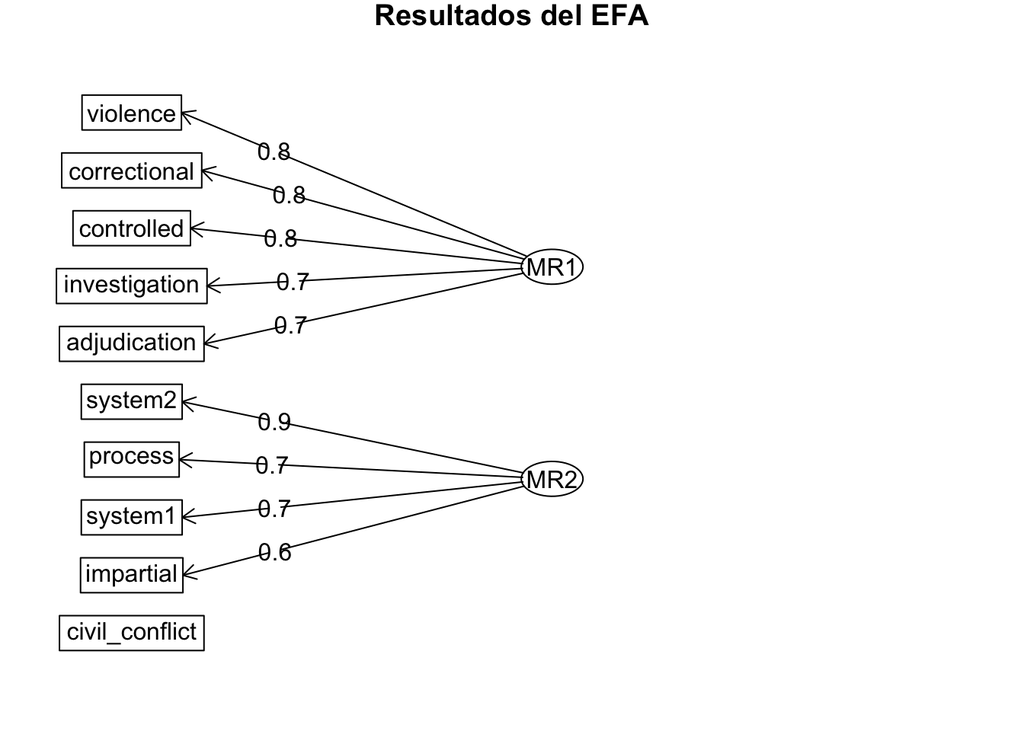

```r
fa.diagram(resfa,main = "Resultados del EFA")
```

```r
sort(resfa$communality)
```

```
## civil_conflict      impartial     controlled       violence  investigation
##      0.1034325      0.6385170      0.6811406      0.7349252      0.7809932
##   adjudication        system2   correctional        system1        process
##      0.7827327      0.8363183      0.8595629      0.8654242      0.9181469
```

Rspta. *process*